# Lab #13 - Additional Topics in Regression Modeling

$~$

This lab covers a few topics in multivariable regression modeling, specifically:

1. Using the $F$-test to compare the fit of nested models
2. Understanding the difference between $R^2$ and adjusted $R^2$
3. Using a log-transformation if a model violates the assumptions for inference

During the first part of the lab you will use the professor salary data. Recall that these data were collected by a large, public university as part of an investigation into possible sex-based differences in faculty pay.

```r
fac_sal = read.csv("https://remiller1450.github.io/data/Salaries.csv")
```

$~$

### The $F$-test for Nested Models

The $F$-test for comparing the fit of nested regression models is fundamentally the same test we learned about when studying one-way ANOVA. So, similarly, the first step in performing the test is to fit the two models of interest. For example:

```r
smaller_model = lm(salary ~ sex, data = fac_sal)
larger_model = lm(salary ~ sex + rank, data = fac_sal)
```

Next we use the `anova()` function to perform the test on these fitted models:

```r
anova(smaller_model, larger_model)
```

```
## Analysis of Variance Table
##
## Model 1: salary ~ sex
## Model 2: salary ~ sex + rank
##   Res.Df        RSS Df  Sum of Sq      F    Pr(>F)
## 1    395 3.5632e+11
## 2    393 2.1923e+11  2 1.3709e+11 122.88 < 2.2e-16 ***
## ---
## Signif. codes:  0 '***' 0.001 '**' 0.01 '*' 0.05 '.' 0.1 ' ' 1
```

Each model’s sum of squared residuals is provided in the “RSS” column, and the degrees of freedom indicate the number of additional parameters used by the larger model. In this example, those parameters are the slope coefficients on the two dummy variables used to encode categories of `rank`.

The small $p$-value indicates the residuals are significantly smaller for the larger model, thus providing strong evidence that the additional predictors (the two dummy variables used to encode `rank`) improve model fit.

Because the $F$-test relies on the assumptions of the larger model, we should use residual diagnostic plots to assess whether those assumptions appear reasonable:

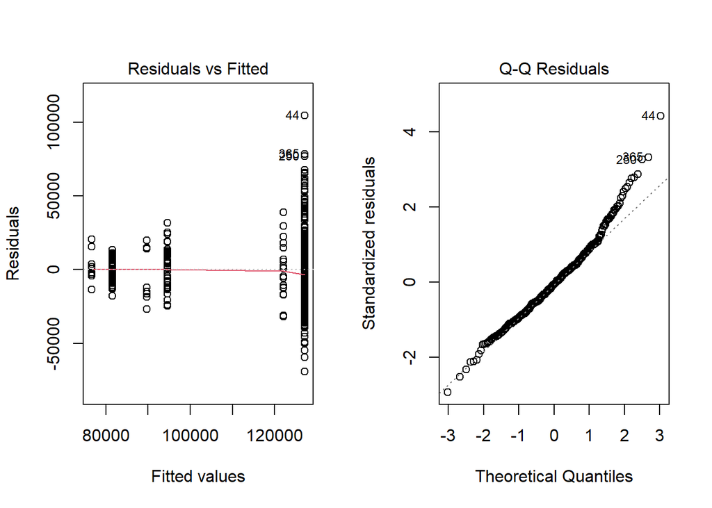

```r
par(mfrow = c(1,2))
plot(larger_model, which = c(1,2))
```

In this plot we see some indication of increasing spread in the residuals for larger fitted values (more variability on the right side of the Residuals vs. Fitted plot), as well as some moderate skew in the residuals (departure from the 45-degree line in the upper right of the QQ-plot).

These violations might lead us to question a borderline $p$-value, but probably aren’t enough to invalidate our overall conclusion. Nevertheless, we’ll try to find a model that better aligns with the assumptions of linear regression as we progress through the lab.

**Question #1**: In [Lab 9](https://remiller1450.github.io/s209f26/lr1.html#Accommodating_Non-linear_Relationships) we saw how to fit regression models using a *quadratic effect*. In this question you will consider linear vs. quadratic effects of the variable `yrs.service`.

- **Part A**: Explain why the model using linear effect of `yrs.service` is nested within the model using a quadratic effect. Which model parameters (coefficients) do they share? Which are only present in the larger model?
- **Part B**: Use an $F$-test to compare the models: `salary ~ sex + yrs.service` and `salary ~ sex + yrs.service + I(yrs.service^2)`. Provide a brief conclusion using the $p$-value of the test.
- **Part C**: The models tested in Part B did not take into account our earlier finding that `rank` is an important predictor of `salary`. For this question, use an $F$-test to compare the models: `salary ~ sex + rank + yrs.service` and `salary ~ sex + rank + yrs.service + I(yrs.service^2)`. Provide a brief conclusion using the $p$-value of the test.
- **Part D**: Now modify the test from Part C to determine if *any* effect of `yrs.service` is warranted in a model that already includes rank by comparing the models: `salary ~ sex + rank` and `salary ~ sex + rank + yrs.service + I(yrs.service^2)` using an F-test. What set of coefficients ($\beta$ parameters) are being tested? What do you conclude from the test?
- **Part E**: Given what you know about *adjusted* versus *marginal* effects and the context of these data, briefly explain why the predictor `yrs.service` doesn’t seem to improve the model fit after adjusting for the effects of `rank`.

$~$

### Adjusted $R^2$

Unlike the $F$-test, which formally tests whether a predictor improves model fit, *adjusted* $R^2$ provides a descriptive measure of model quality that penalizes unnecessary complexity.

Recall from our lecture slides that adjusted $R^2$ is defined:
$$R^2_{\text{adj}} = 1 - \frac{(1 - R^2)(n - 1)}{n
- k - 1}$$

The purpose of adjusted $R^2$ is to provide a measure of model fit that doesn’t always improve when model complexity is increased; however, the downside is that the metric can no longer be interpreted as the proportion of variation in the outcome variable that is explained by the model.

**Question #2**: For this question you will consider the baseline model: `salary ~ sex + rank`

- **Part A**: Use the `summary()` function to find the $R^2$ and adjusted $R^2$ of the baseline model.
- **Part B**: Add `discipline` to the baseline model and find the new $R^2$ and adjusted $R^2$. Did this additional predictor seem to improve the model fit?
- **Part C**: Interpret the results of the $T$-test in the output given by the `summary()` function in the previous part on the model coefficient of the dummy variable `disciplineB`.
- **Part D**: Now add `yrs.since.phd` to the baseline model and find the new $R^2$ and adjusted $R^2$. Did this additional predictor seem to improve the model fit? *Note*: do not include `discipline` for this question.
- **Part E**: Interpret the results of the $T$-test in the output given by the `summary()` function in the previous part on the model coefficient of the variable `yrs.since.phd`.
- **Part F**: Considering your findings in Parts A-E, explain why predictors that produce small $p$-values in coefficient tests tend to increase adjusted $R^2$, while predictors with large $p$-values often do not.

$~$

### Log-Transformation

In the first section of this lab we saw a QQ-plot showing that the right-tail of the residual distribution is longer than would be expected in a Normal distribution, calling into question whether the data align with the assumptions of the model. Log-transformations are commonly used in this situation because they often reduce right-skewness and lessen the influence of unusually large observations.

As we’ve seen previously, the log-transformation can be done directly in the model formula that we give the `lm()` function:

```r
log_model = lm(log(salary) ~ sex + rank, data = fac_sal)
summary(log_model)
```

```
##
## Call:
## lm(formula = log(salary) ~ sex + rank, data = fac_sal)
##
## Residuals:
##      Min       1Q   Median       3Q      Max
## -0.76503 -0.13371  0.00085  0.12828  0.62276
##
## Coefficients:
##              Estimate Std. Error t value Pr(>|t|)
## (Intercept)  11.40054    0.03668 310.803  < 2e-16 ***
## sexMale       0.04520    0.03281   1.378    0.169
## rankAsstProf -0.14396    0.03365  -4.279 2.37e-05 ***
## rankProf      0.28403    0.02696  10.536  < 2e-16 ***
## ---
## Signif. codes:  0 '***' 0.001 '**' 0.01 '*' 0.05 '.' 0.1 ' ' 1
##
## Residual standard error: 0.1925 on 393 degrees of freedom
## Multiple R-squared:  0.4568, Adjusted R-squared:  0.4526
## F-statistic: 110.1 on 3 and 393 DF,  p-value: < 2.2e-16
```

Now let’s reassess our model’s assumptions after the log-transformation:

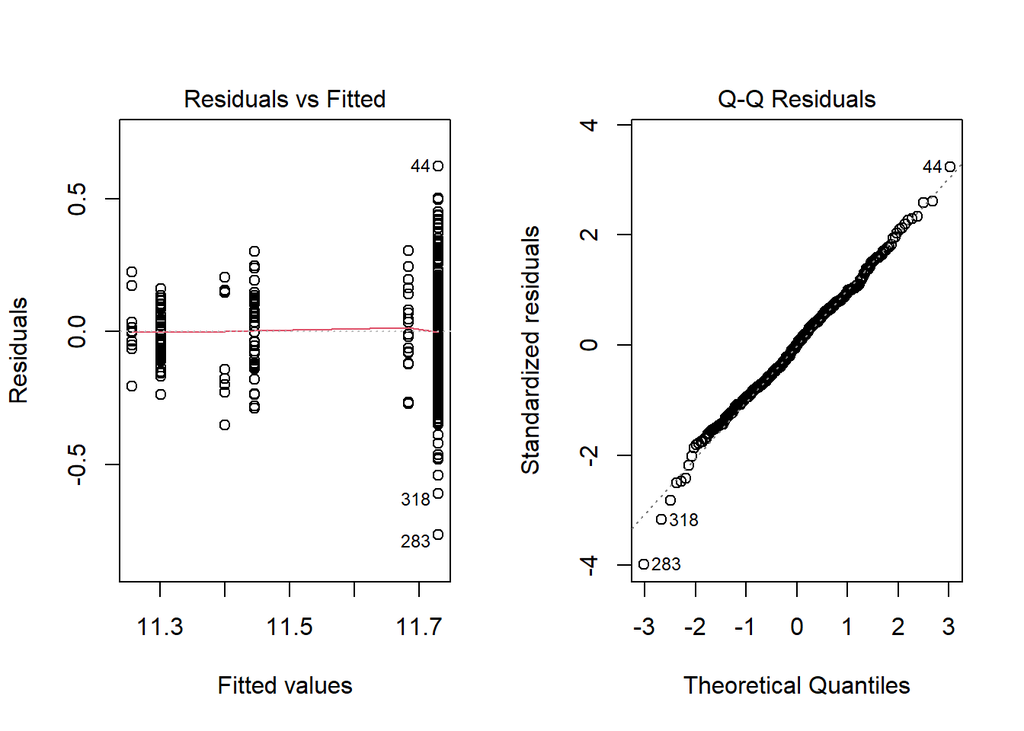

```r
par(mfrow = c(1,2))
plot(log_model, which = c(1,2))
```

**Question #3**:

- **Part A**: Fit the model: `log(salary) ~ sex + rank + discipline`, which is arguably the best model based upon what we’ve seen so far throughout this lab. Print a `summary()` of this model and report its $R^2$ and adjusted $R^2$. How do these compare with the values you had seen in Question #2?
- **Part B**: Interpret the $T$-test on the coefficient of `sexMale` in the model from Part A. Does there appear to be convincing statistical evidence of a difference in male versus female salaries after adjusting for differences in rank and discipline?
- **Part C**: Undo the log-transformation and interpret the adjusted effect of `disciplineB`. That is, describe how the expected salary in discipline “B” differs from the expected salary in discipline “A” after adjusting for differences in rank and sex.
- **Part D**: Use the `plot()` function to create residual diagnostic plots for the model from Part A. Briefly describe how you feel about the constant variance and normality of residuals assumptions.